# ChickR - ggplot2

S Bashir (ilustat.com)

26 October 2016

## ChickR

Welcome to ChickR

### Setup

It is assumed that the latest version of R is installed on your computer. It is recommended that you install and use [Rstudio IDE](https://www.rstudio.com/products/rstudio/) (integrated development environment) for the ChickR series. Other IDEs should work fine. The first step is to install some packages (*addons*/*apps*) by typing the following in the console:

```r
install.packages("tidyverse")
```

It could take some time to download and install. Without going into details, we next need to *active* some of these packages as we will be using them without directly realising. So please type the following in the console:

```r
library(dplyr)
library(ggplot2)
```

### ChickWeight Data

The `ChickWeight` data is one of the many datasets included as part of R. The data are from a weight gain experiment for chicks. We will start by loading the data and looking at it.

```r
data("ChickWeight")
glimpse(ChickWeight)
```

```
## Observations: 578
## Variables: 4
## $ weight <dbl> 42, 51, 59, 64, 76, 93, 106, 125, 149, 171, 199, 205, 4...
## $ Time   <dbl> 0, 2, 4, 6, 8, 10, 12, 14, 16, 18, 20, 21, 0, 2, 4, 6, ...
## $ Chick  <ord> 1, 1, 1, 1, 1, 1, 1, 1, 1, 1, 1, 1, 2, 2, 2, 2, 2, 2, 2...
## $ Diet   <fctr> 1, 1, 1, 1, 1, 1, 1, 1, 1, 1, 1, 1, 1, 1, 1, 1, 1, 1, ...
```

We can see that there are 4 variables and 578 observations. Each chick in the experiment is uniquely identified by the `Chick` variable (**R is case sensitive**) and they are randomly assigned to be fed one of four diets (`Diet`). Their `weight` (in grams) is measured over `Time` (from day zero to day 21).

### ChickWeight Objective

Our objective is to investigate the effect of diet on the chieck weights over time.

### Graphical Exploration

We will start by looking the data graphically using the `ggplot2` package. Don’t worry too much about the details of the commands just try to build your own understanding.

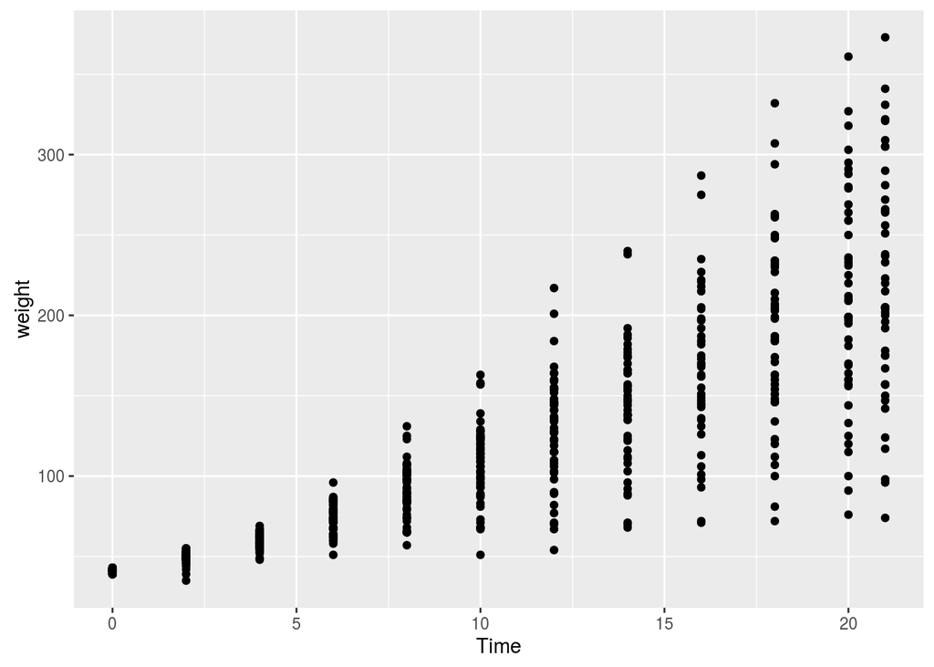

```r
ggplot(ChickWeight, aes(Time, weight)) + geom_point()
```

We see that generally the chick weights increase over time but what is the effect of diet?

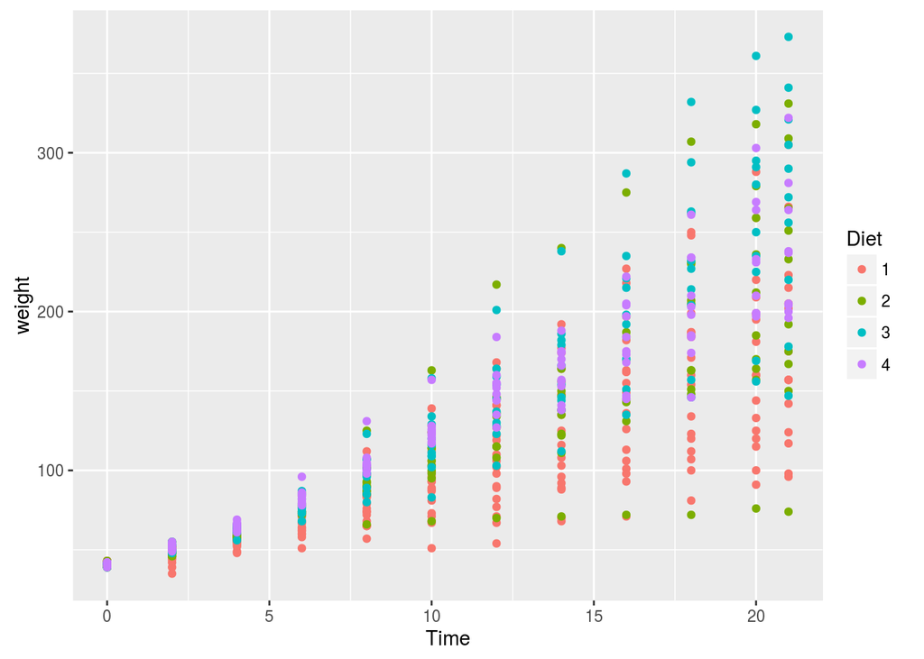

```r
ggplot(ChickWeight, aes(Time, weight, colour = Diet)) + geom_point()
```

It is hard to make out the effect of the diet as there are many overlapping points.

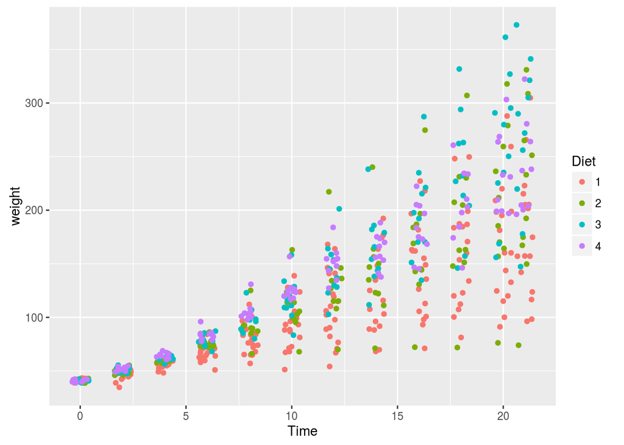

```r
ggplot(ChickWeight, aes(Time, weight, colour = Diet)) + geom_jitter()
```

This looks like four hives of bees spreading out so still not easy to see what the effect of diet.

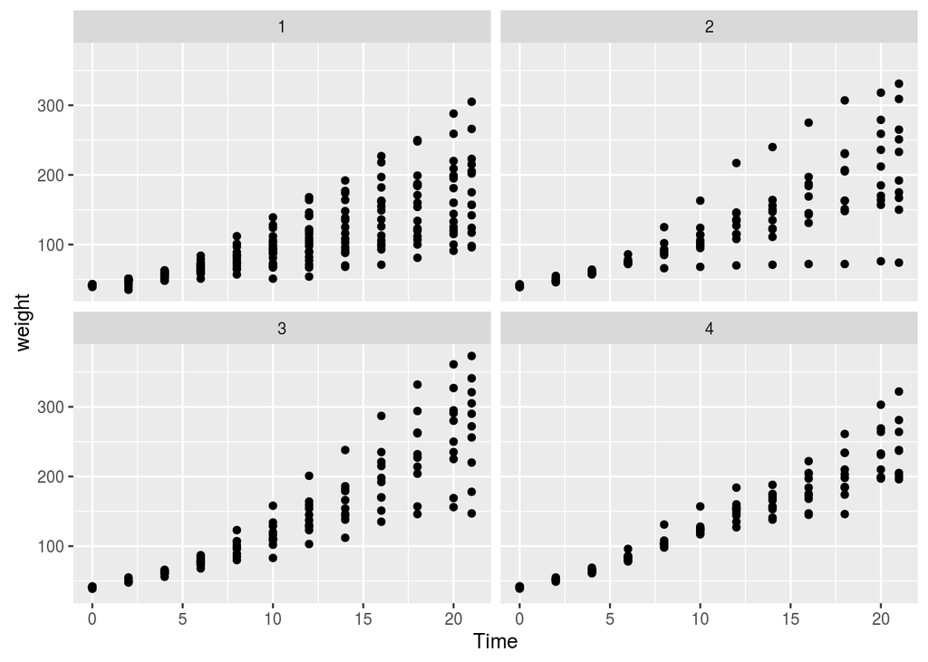

```r
ggplot(ChickWeight, aes(Time, weight)) + geom_point() + facet_wrap(~Diet)
```

Perhaps it will look better with a bit of colour

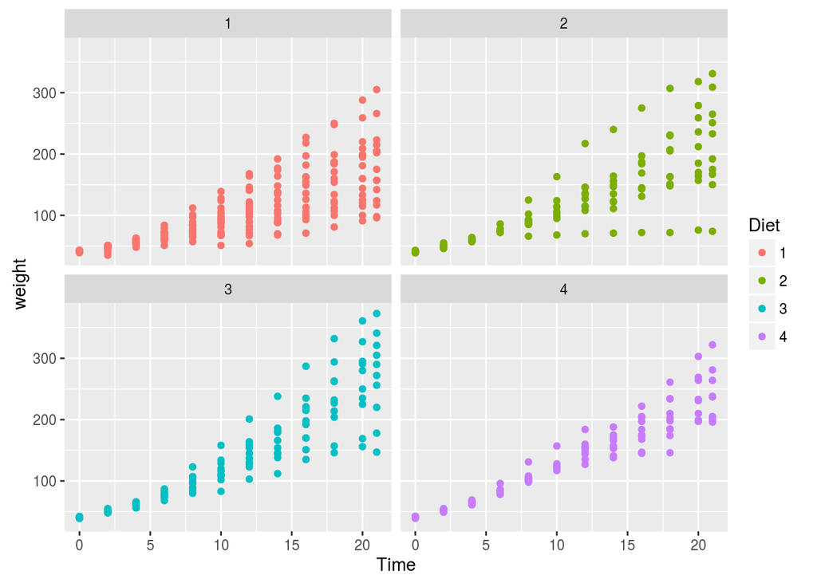

```r
ggplot(ChickWeight, aes(Time, weight, colour = Diet)) + geom_point() + facet_wrap(~Diet)
```